# Procesamiento de datos en tiempo real con Kafka

#### 3. Procesamiento en tiempo real de sensores

En esta practica el objetivo es escribir una aplicacion que procese los datos del topic sensor-telemetry

Cuando se detecten condiciones anómalas de temperatura mayores a 35 grados o humedad de menos 20% debe enviar esas alertas a **sensor-alerts** con un formato tipo de mensaje:

```json
{
  "sensor_id": "sensor_001",
  "alert_type": "HIGH_TEMPERATURE",
  "timestamp": 1741479493000,
  "details": "Temperature exceeded 35C"
}
```

Para esto se ha creado la aplicación SensorAlerterApp.java La App se encuentra aqui: src/main/java/com/farmia/streaming/SensorAlerterApp.java

Algunos puntos de interés:

En la app se indica el topic de entrada y salida

```java
private static final String INPUT_TOPIC = "sensor-telemetry";
private static final String OUTPUT_TOPIC = "sensor-alerts";
private static final String SCHEMA_REGISTRY_URL = "http://localhost:8081";
```

El filtro solicitado

```java
.filter((key, record) -> {
    float temperature = (float) record.get("temperature");
    float humidity = (float) record.get("humidity");
    return temperature > 35.0f || humidity < 20.0f;
})
```

Con este comando mvn exec:java -Dexec.mainClass=“com.farmia.streaming.SensorAlerterApp” se ejecuta la App En la terminal se puede ver la generacion de mensajes con picos de temperatura y/o humedad

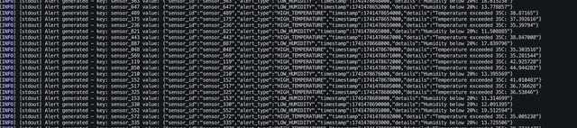

Sensor Alerts

Y en el control center un detalle del mensaje generado el cual es acorde a lo solicitado en la practica

```json
{
  "sensor_id": "sensor_717",
  "alert_type": "HIGH_TEMPERATURE",
  "timestamp": 1741479493000,
  "details": "Temperature exceeded 35C: 35.15159"
}
{
  "sensor_id": "sensor_127",
  "alert_type": "LOW_HUMIDITY",
  "timestamp": 1741479939000,
  "details": "Humidity below 20%: 17.266754"
}
```

#### 4. Procesamiento en tiempo real de transacciones de ventas

Tal como en el caso anterior, el objetivo aquí es generar una App que procese sales-transactions donde sea capaz de agrupar los datos por categoría de producto y calcule los ingresos por categoría cada un minuto.

El topic que recibirá estos mensajes es **sales-summary** con un tipo de mensaje especifico:

```json
{
  "category": "fertilizers",
  "total_quantity": 20,
  "total_revenue": 1000.10,
  "window_start": 1773515220000,
  "window_end": 1773515280000
}
```

La App se encuentra aquí: src/main/java/com/farmia/streaming/SalesSummaryApp.java. Dentro del archivo se encuentran las configuraciones para poder generar las agregaciones

```java
private static final String INPUT_TOPIC = "sales-transactions";
private static final String OUTPUT_TOPIC = "sales-summary";
private static final String SCHEMA_REGISTRY_URL = "http://localhost:8081";
```

En este apartado del código (lineas 37 a 44) se configura la agrupación por categoría y el procesamiento en intervalos de un minuto.

```java
// Configuracion de los requerimientos de agrupacion de los datos de categoria x minuto
    .groupBy(
        (key, record) ->record.get("category").toString(),
        Grouped.with(Serdes.String(), genericAvroSerde))
// Configura el procesamiento en intervalos de 1 minuto
    .windowedBy(
        TimeWindows.ofSizeWithNoGrace(Duration.ofMinutes(1))
)
```

Y aquí es donde se configura el criterio de agregación para calcular el total de ingresos

```java
// Criterios de agregacion para obtener el totalRevenue
    .aggregate(
// Cuando llega la primera transaccion este es el valor de partida
    () -> "0,0.0",
    (category, record, accumulator) -> {
    String[] parts = accumulator.split(",");
    int totalQuantity = Integer.parseInt(parts[0]) + (int) record.get("quantity");
// Este bloque convierte el decimal de MySql a formato double
    Conversions.DecimalConversion decimalConversion = new org.apache.avro.Conversions.DecimalConversion();
    org.apache.avro.Schema priceSchema = record.getSchema().getField("price").schema();
    double price = decimalConversion.fromBytes(
    (java.nio.ByteBuffer) record.get("price"),
    priceSchema,
    priceSchema.getLogicalType()
).doubleValue();
```

Dado que en MySql la columna price viene con formato decimal, se ha utilizado un conversor de avro para convertirlo a doubleValue y desplegar el formato correcto en el mensaje saliente (ver lineas 53 al 59)

Es momento de ejecutar la aplicacion con el comando mvn exec:java -Dexec.mainClass=“com.farmia.streaming.SalesSummaryApp” En la terminal se ve la generación de mensajes:

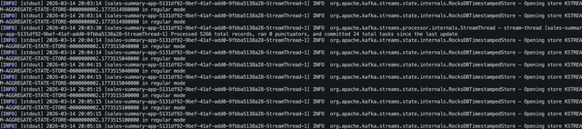

Sales Summary

En el control center se puede ver un mensaje en formato json:

```json
{
  "category": "seeds",
  "total_quantity": 22,
  "total_revenue": 3260.85,
  "window_start": 1773514260000,
  "window_end": 1773514320000
}
```

Durante la creación de las App al ejecutar por primera vez con el comando mvn daba error de compilación y cerraba sin procesar mensajes. Para resolver esto en ambas App se añadió al bloque main un InterruptedException y un Thread.currentThread().join() con el join se evita que se cierre sin enviar mensajes:

```java
    public static void main(String[] args) throws IOException, InterruptedException {
        Properties props = new Properties();
        props.put(StreamsConfig.APPLICATION_ID_CONFIG, "sensor-alerter-app");
        props.put(StreamsConfig.BOOTSTRAP_SERVERS_CONFIG, "localhost:9092,localhost:9093,localhost:9094");
        props.put("schema.registry.url", SCHEMA_REGISTRY_URL);

        Topology topology = createTopology();
        KafkaStreams streams = new KafkaStreams(topology, props);
        streams.start();
        Runtime.getRuntime().addShutdownHook(new Thread(streams::close));
        // esto evita que los hilos terminen a los segundos sin enviar mensajes
        Thread.currentThread().join();
    }
}
```

#### 5. Integración de MongoDB con Kafka Connect

El objetivo de esta ultima practica es escribir los datos de sensor-alerts a una coleccion en MongoDB utilizando un sink connector Para esto se ha creado el conector **sink-mongodb-sensor_alerts.json**

```json
{
  "name": "sink-mongodb-sensor_alerts",
  "config": {
    "connector.class": "com.mongodb.kafka.connect.MongoSinkConnector",
    "topics": "sensor-alerts",
    "connection.uri": "mongodb://admin:secret123@mongodb:27017",
    "database": "farmia",
    "collection": "sensor_alerts",
    "tasks.max": "1",
    "value.converter": "org.apache.kafka.connect.storage.StringConverter",
    "value.converter.schemas.enable": "false",
    "key.converter": "org.apache.kafka.connect.storage.StringConverter",
    "document.id.strategy": "com.mongodb.kafka.connect.sink.processor.id.strategy.BsonOidStrategy"
  }
}
```

A modo de repaso, estos mensajes de alerta se generan desde la App SensorAlerter que ya ha enviado mensajes al control center de tipo

```json
{
  "sensor_id": "sensor_716",
  "alert_type": "HIGH_TEMPERATURE",
  "timestamp": 1741482888000,
  "details": "Temperature exceeded 35C: 38.30977"
}
```

Con el sink conector se envían estos mensajes generados en sensor-alerts a mongo. En la terminal se puede revisar como se van generando los mensajes que estan llegando a mongoDB. Utilizando bash es posible generar los mensajes en formato json.

```bash
while true; do
    docker exec mongodb mongosh -u admin -p secret123 --quiet \
      --eval 'db.getSiblingDB("farmia").sensor_alerts.find().sort({$natural:-1}).limit(5).forEach(doc => print(EJSON.stringify(doc, null, 2)))'
    sleep 0.5
  done
```

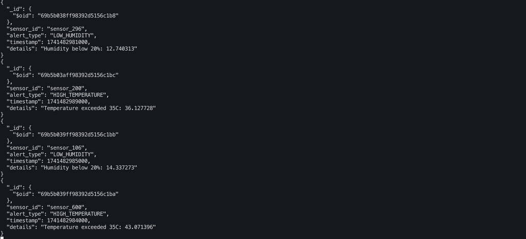

Mongo

También se puede revisar en Mongo compass

[figure not shown]

Mongo Compass

Con esto se cubre la practica completa donde se ha explorado el ciclo de obtener datos, agruparlos, crear nuevos mensajes a partir de los datos entrantes e interactuar con bases de datos relacionales y no sql. Al momento de terminar la practica es momento de detener el container utilizando ./shutdown.sh.

```bash
Deteniendo entorno
[+] Running 14/13
 ✔ Container mongodb             Removed                                                                                                                                                1.7s
 ✔ Container control-center      Removed                                                                                                                                                7.8s
 ✔ Container ksqldb-cli          Removed                                                                                                                                                0.8s
 ✔ Container mysql               Removed                                                                                                                                                7.7s
 ✔ Container ksqldb-server       Removed                                                                                                                                                3.3s
 ✔ Container connect             Removed                                                                                                                                               13.2s
 ✔ Container schema-registry     Removed                                                                                                                                                2.6s
 ✔ Container broker-2            Removed                                                                                                                                                5.4s
 ✔ Container broker-1            Removed                                                                                                                                                5.3s
 ✔ Container broker-3            Removed                                                                                                                                                5.3s
 ✔ Container controller-3        Removed                                                                                                                                                7.2s
 ✔ Container controller-1        Removed                                                                                                                                                1.7s
 ✔ Container controller-2        Removed                                                                                                                                                1.7s
 ✔ Network 1environment_default  Removed                                                                                                                                                0.1s
OK
```

## Licencia

Todos los derechos reservados